# Red Wine Exploration

Danielle Taneyo

Monday, October 31, 2016

========================================================

This is my exploration of the red wine data. To assess the quality of a wine, it can be use sensorial analysis and physicochemical analysis. In this project I will explore the data from Cortez et al., 2009.

### Load the packages and read the data

#### New function

```r
describe <- function(df, col){
v <- df[, col]
sumry <- summary(v)
ns <- names(sumry)
ns <- c(ns, 'std')
out <- c(sumry, sd(v))
names(out) <- ns
round(out, digit = 3)
}
```

```
##   fixed.acidity volatile.acidity citric.acid residual.sugar chlorides
## 1           7.4             0.70        0.00            1.9     0.076
## 2           7.8             0.88        0.00            2.6     0.098
## 3           7.8             0.76        0.04            2.3     0.092
## 4          11.2             0.28        0.56            1.9     0.075
## 5           7.4             0.70        0.00            1.9     0.076
## 6           7.4             0.66        0.00            1.8     0.075
##   free.sulfur.dioxide total.sulfur.dioxide density   pH sulphates alcohol
## 1                  11                   34  0.9978 3.51      0.56     9.4
## 2                  25                   67  0.9968 3.20      0.68     9.8
## 3                  15                   54  0.9970 3.26      0.65     9.8
## 4                  17                   60  0.9980 3.16      0.58     9.8
## 5                  11                   34  0.9978 3.51      0.56     9.4
## 6                  13                   40  0.9978 3.51      0.56     9.4
##   quality
## 1       5
## 2       5
## 3       5
## 4       6
## 5       5
## 6       5
```

```
## 'data.frame':    1599 obs. of  12 variables:
##  $ fixed.acidity       : num  7.4 7.8 7.8 11.2 7.4 7.4 7.9 7.3 7.8 7.5 ...
##  $ volatile.acidity    : num  0.7 0.88 0.76 0.28 0.7 0.66 0.6 0.65 0.58 0.5 ...
##  $ citric.acid         : num  0 0 0.04 0.56 0 0 0.06 0 0.02 0.36 ...
##  $ residual.sugar      : num  1.9 2.6 2.3 1.9 1.9 1.8 1.6 1.2 2 6.1 ...
##  $ chlorides           : num  0.076 0.098 0.092 0.075 0.076 0.075 0.069 0.065 0.073 0.071 ...
##  $ free.sulfur.dioxide : num  11 25 15 17 11 13 15 15 9 17 ...
##  $ total.sulfur.dioxide: num  34 67 54 60 34 40 59 21 18 102 ...
##  $ density             : num  0.998 0.997 0.997 0.998 0.998 ...
##  $ pH                  : num  3.51 3.2 3.26 3.16 3.51 3.51 3.3 3.39 3.36 3.35 ...
##  $ sulphates           : num  0.56 0.68 0.65 0.58 0.56 0.56 0.46 0.47 0.57 0.8 ...
##  $ alcohol             : num  9.4 9.8 9.8 9.8 9.4 9.4 9.4 10 9.5 10.5 ...
##  $ quality             : int  5 5 5 6 5 5 5 7 7 5 ...
```

```
##  fixed.acidity   volatile.acidity  citric.acid    residual.sugar
##  Min.   : 4.60   Min.   :0.1200   Min.   :0.000   Min.   : 0.900
##  1st Qu.: 7.10   1st Qu.:0.3900   1st Qu.:0.090   1st Qu.: 1.900
##  Median : 7.90   Median :0.5200   Median :0.260   Median : 2.200
##  Mean   : 8.32   Mean   :0.5278   Mean   :0.271   Mean   : 2.539
##  3rd Qu.: 9.20   3rd Qu.:0.6400   3rd Qu.:0.420   3rd Qu.: 2.600
##  Max.   :15.90   Max.   :1.5800   Max.   :1.000   Max.   :15.500
##    chlorides       free.sulfur.dioxide total.sulfur.dioxide
##  Min.   :0.01200   Min.   : 1.00       Min.   :  6.00
##  1st Qu.:0.07000   1st Qu.: 7.00       1st Qu.: 22.00
##  Median :0.07900   Median :14.00       Median : 38.00
##  Mean   :0.08747   Mean   :15.87       Mean   : 46.47
##  3rd Qu.:0.09000   3rd Qu.:21.00       3rd Qu.: 62.00
##  Max.   :0.61100   Max.   :72.00       Max.   :289.00
##     density             pH          sulphates         alcohol
##  Min.   :0.9901   Min.   :2.740   Min.   :0.3300   Min.   : 8.40
##  1st Qu.:0.9956   1st Qu.:3.210   1st Qu.:0.5500   1st Qu.: 9.50
##  Median :0.9968   Median :3.310   Median :0.6200   Median :10.20
##  Mean   :0.9967   Mean   :3.311   Mean   :0.6581   Mean   :10.42
##  3rd Qu.:0.9978   3rd Qu.:3.400   3rd Qu.:0.7300   3rd Qu.:11.10
##  Max.   :1.0037   Max.   :4.010   Max.   :2.0000   Max.   :14.90
##     quality
##  Min.   :3.000
##  1st Qu.:5.000
##  Median :6.000
##  Mean   :5.636
##  3rd Qu.:6.000
##  Max.   :8.000
```

As the first view, he have some variables with a high range like residual.sugar, total.sulfur.dioxide, citric.acid, free.sulfur.dioxide and volatile.acidity. The quality variable is the dependent or response variable, it’s a sensorial score between 0 and 10, 0 is worst and 10 best.In this data the score is between 3 and 8 with an average of 5.6. I will try to respond to 2 questions here:  
1. Which properties can influence the wine quality?  
2. Is there some relation between these properties?

# Univariate Plots Section

### Sulphates

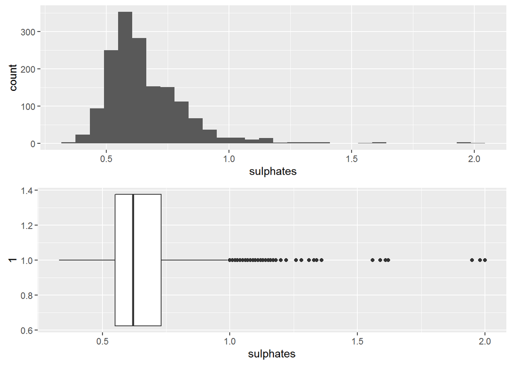

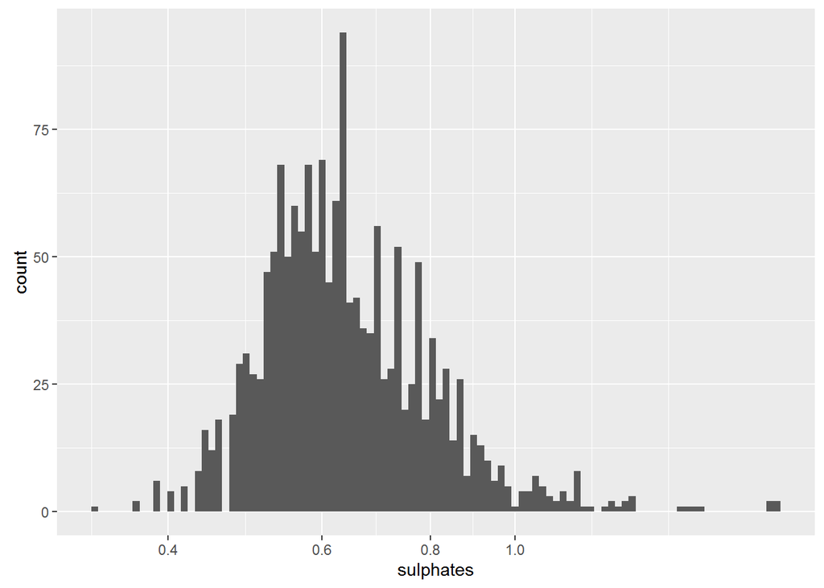

```
##    Min. 1st Qu.  Median    Mean 3rd Qu.    Max.     std
##   0.330   0.550   0.620   0.658   0.730   2.000   0.170
```

## Questions for the reviewers

- To respond to the last review and have some advices, my original thinking was to first show the original distribution and then the one log transformed without outliers like in this one but I though it was too much because I want to do it for all the variables with outliers, so it’s not to much like this?

The sulphate is a wine additive use as an antimicrobial and antioxidant. The first plot show a skew distribution so I transformed the data to better understand the distribution. The log transformed data shows the highest peak at around 0.6 with several gaps.

First let’s create another factor variable for the quality in order to have an ordinal variable.

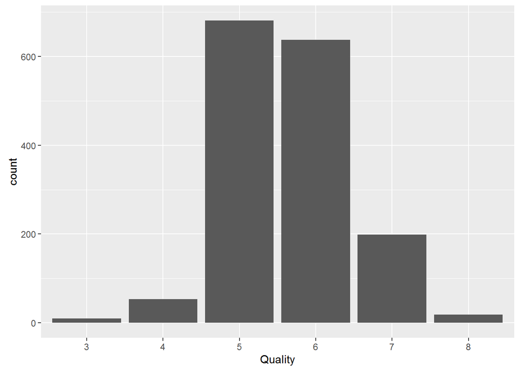

Most of the wine are medium quality 5 and 6.

### pH

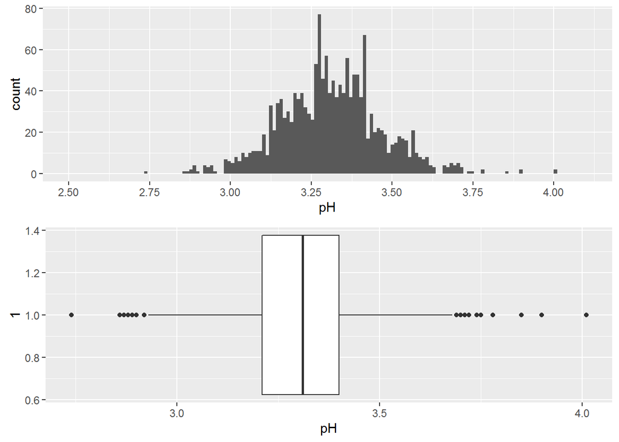

Many wine have a pH around 3.3, we see also some gaps in the distribution.

### Total sulphur dioxide

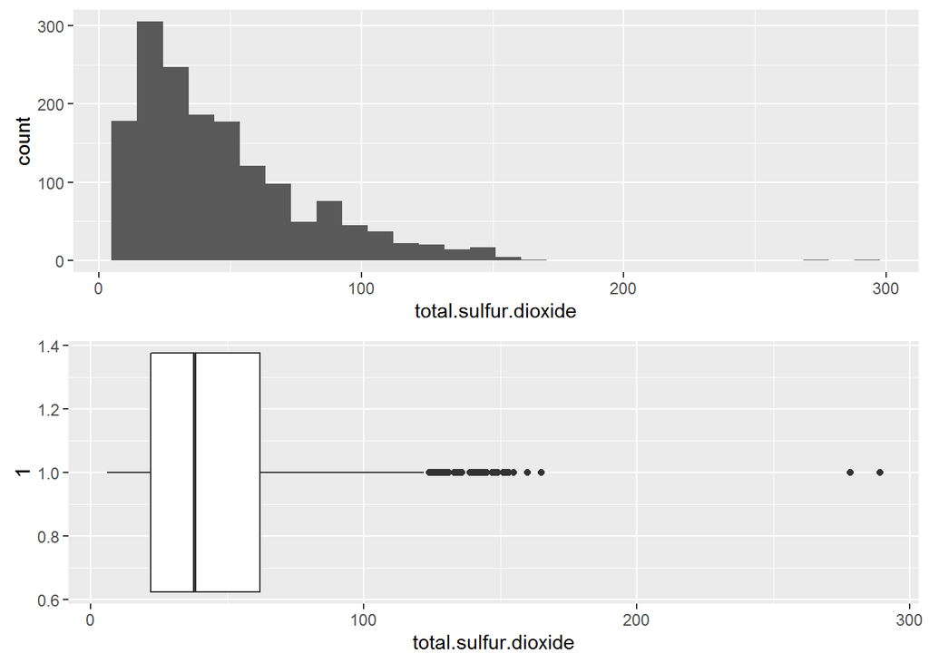

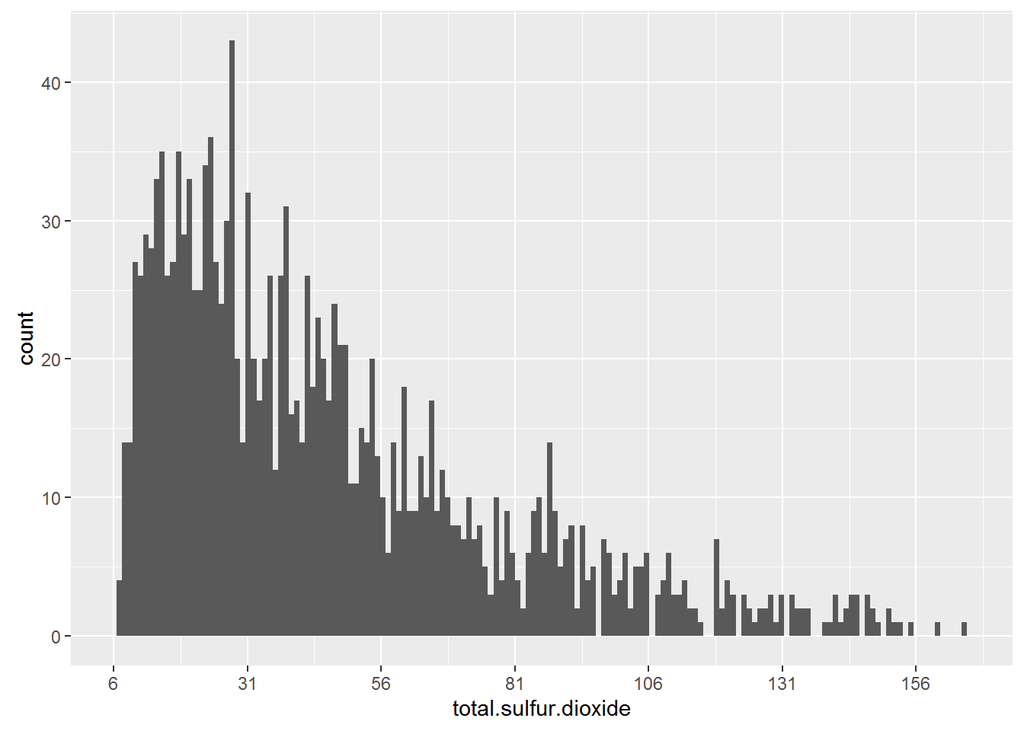

```
##    Min. 1st Qu.  Median    Mean 3rd Qu.    Max.     std
##   6.000  22.000  38.000  46.470  62.000 289.000  32.895
```

The histogram of total sulfur dioxide show a right-skewed distribution, most of the wines have a content around 29, we have a big gap between 165 and 281. The median is 38 with the maximun value of 289. I will subset the data and consider values less than 165.

### Alcohol

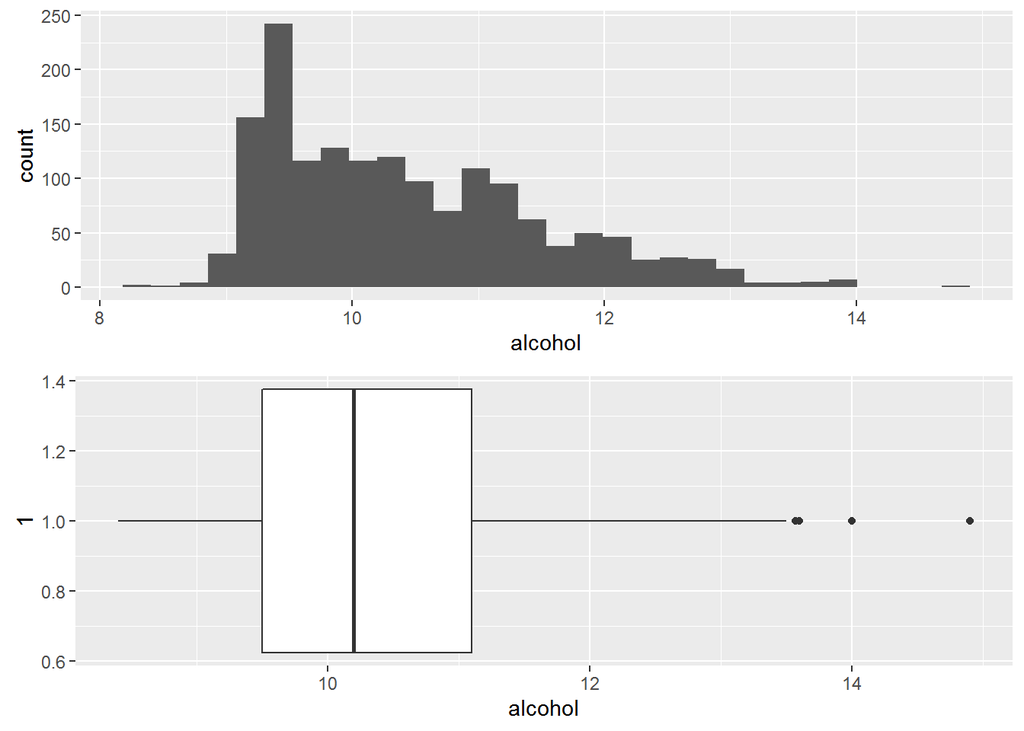

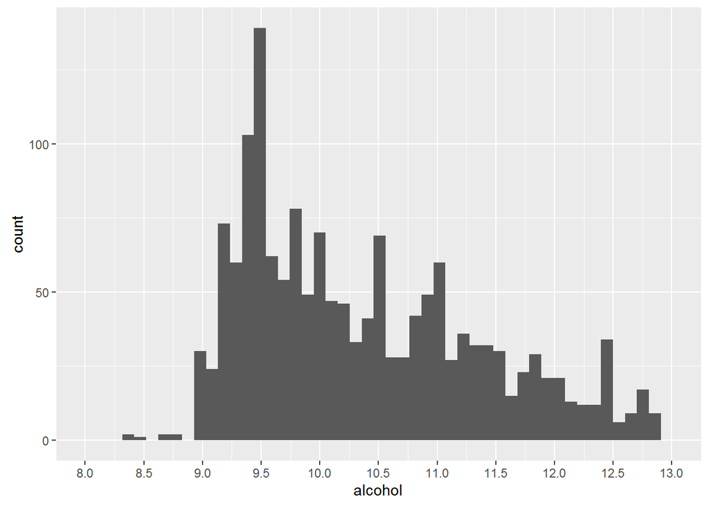

```
##    Min. 1st Qu.  Median    Mean 3rd Qu.    Max.     std
##   8.400   9.500  10.200  10.420  11.100  14.900   1.066
```

Most wine had an alcohol percent around 9.5, the maximun value is 14.90 maybe an outlier?

### Volatile acidity

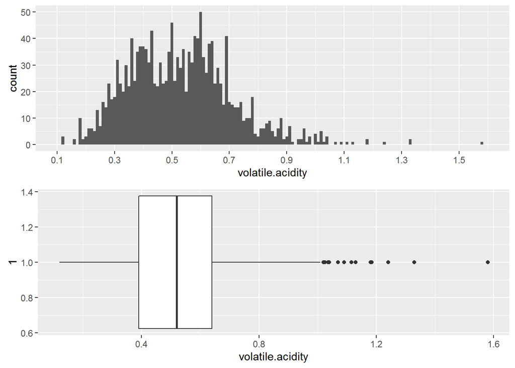

```
##    Min. 1st Qu.  Median    Mean 3rd Qu.    Max.     std
##   0.120   0.390   0.520   0.528   0.640   1.580   0.179
```

The volatile acidity is an indicator of spoiled wine, so high content indicates wine with worst quality, most wines have a volatile acidity around 0.6. The average value is 0.53.

### Citric acid

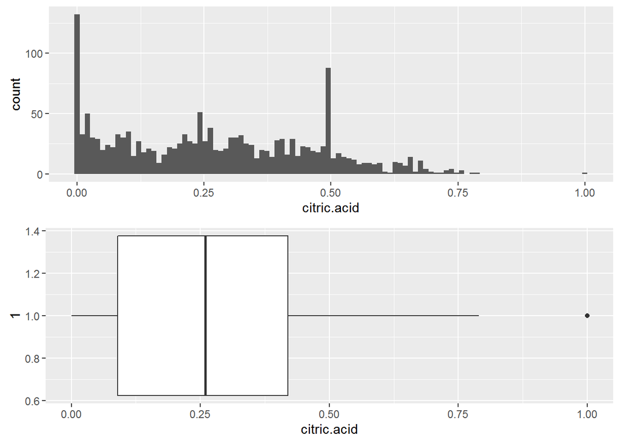

```
##    Min. 1st Qu.  Median    Mean 3rd Qu.    Max.     std
##   0.000   0.090   0.260   0.271   0.420   1.000   0.195
```

### Residual.sugar

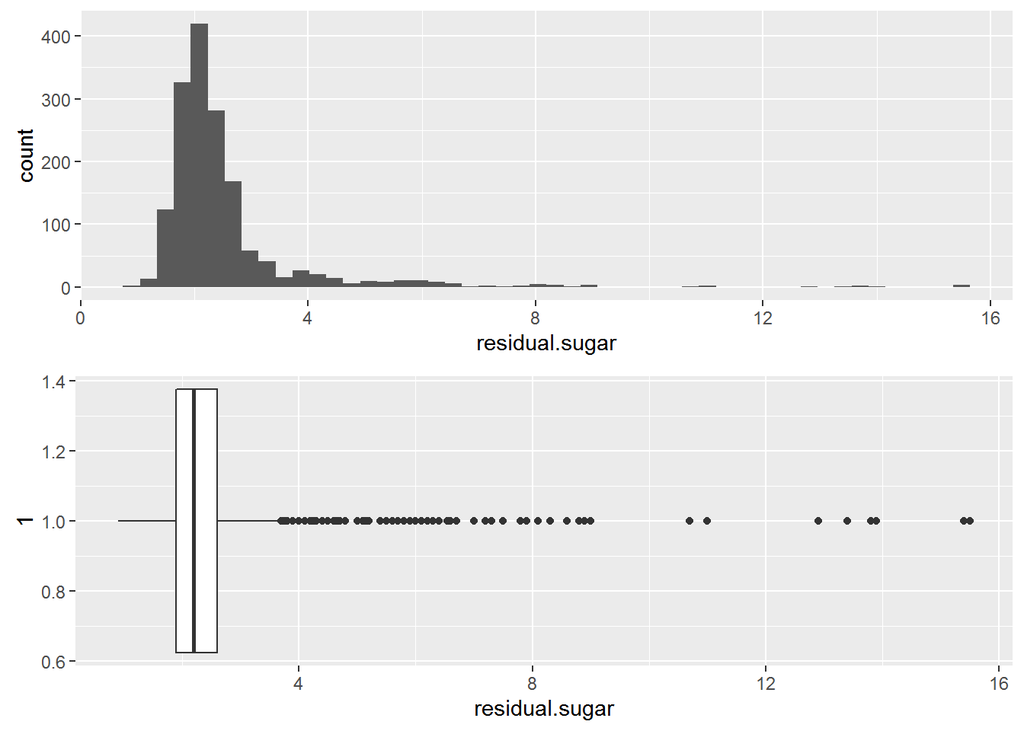

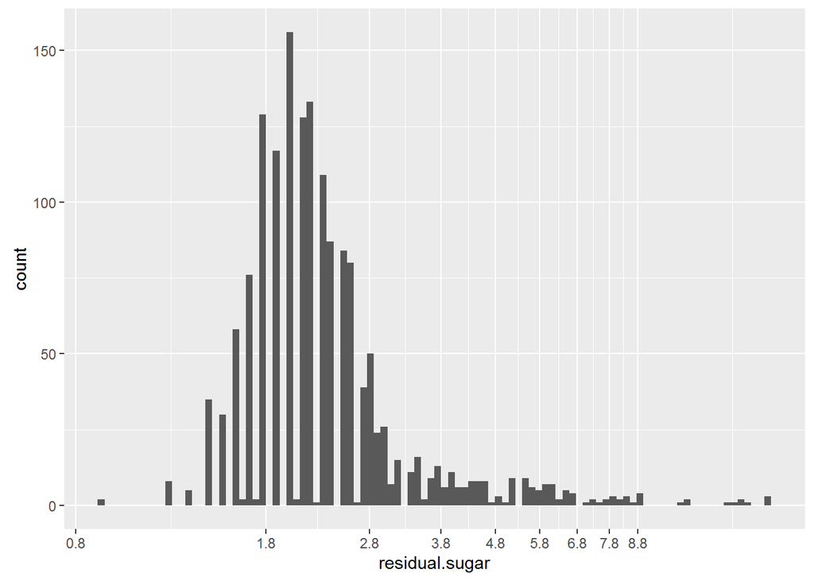

```
##    Min. 1st Qu.  Median    Mean 3rd Qu.    Max.     std
##   0.900   1.900   2.200   2.539   2.600  15.500   1.410
```

The histogram of residual sugar is right-skewed and the range is high. The transformed histogram shows that most wines have a residual sugar around 2.2, few have an amount greater than 3. 75% of the wine have a residual sugar less than 2.6, and the average is 2.5.

# Univariate Analysis

### What is the structure of your dataset?

This data consist of 1599 red wines with 11 variables of their chemical properties. The 11 variables:

1. fixed acidity (tartaric acid - g/dm^3)
2. volatile acidity (acetic acid - g/dm^3)
3. citric acid (g/dm^3)
4. residual sugar (g/dm^3)
5. chlorides (sodium chloride - g/dm^3
6. free sulfur dioxide (mg/dm^3)
7. total sulfur dioxide (mg/dm^3)
8. density (g/cm^3)
9. pH
10. sulphates (potassium sulphate - g/dm3)
11. alcohol (% by volume)

### What is/are the main feature(s) of interest in your dataset?

The main features of interest is the sulphate content, pH, alcohol, total sulfur dioxide.

### What other features in the dataset do you think will help support your investigation into your feature(s) of interest?

Volatile acidity, citric acid and residual sugar are interesting features to support the analysis as they are also use as indicators in the fermentation process of wine.

### Did you create any new variables from existing variables in the dataset?

I create a new variable to convert the quality in ordinal factor.

### Of the features you investigated, were there any unusual distributions? Did you perform any operations on the data to tidy, adjust, or change the form of the data? If so, why did you do this?

Sulphates and residual sugar distributions were right-skewed so I log transformed them. Transforming the data I saw that the peak was around 0.6 for sulphates and 2.2 for residual sugar.  
For others variable I adjust the binwidth and the scale to have a better view of small values.

# Bivariate Plots Section

### Sulphates

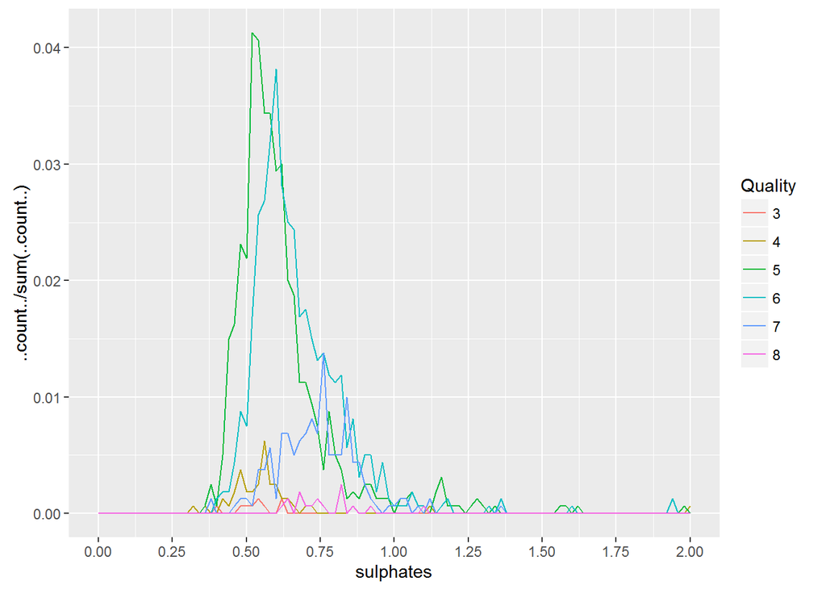

```
## wine$quality: 3
##    Min. 1st Qu.  Median    Mean 3rd Qu.    Max.
##  0.4000  0.5125  0.5450  0.5700  0.6150  0.8600
## --------------------------------------------------------
## wine$quality: 4
##    Min. 1st Qu.  Median    Mean 3rd Qu.    Max.
##  0.3300  0.4900  0.5600  0.5964  0.6000  2.0000
## --------------------------------------------------------
## wine$quality: 5
##    Min. 1st Qu.  Median    Mean 3rd Qu.    Max.
##   0.370   0.530   0.580   0.621   0.660   1.980
## --------------------------------------------------------
## wine$quality: 6
##    Min. 1st Qu.  Median    Mean 3rd Qu.    Max.
##  0.4000  0.5800  0.6400  0.6753  0.7500  1.9500
## --------------------------------------------------------
## wine$quality: 7
##    Min. 1st Qu.  Median    Mean 3rd Qu.    Max.
##  0.3900  0.6500  0.7400  0.7413  0.8300  1.3600
## --------------------------------------------------------
## wine$quality: 8
##    Min. 1st Qu.  Median    Mean 3rd Qu.    Max.
##  0.6300  0.6900  0.7400  0.7678  0.8200  1.1000
```

The frequency polygon plot of sulphates shows that the gap we first see are from the 4, 5, 6 qualities. In fact the summary shows that 75% of the suphates in these wine are less than 0.6 and 0.75. May be I should subset the data and remove these. The median and mean also show that the sulphates increase as the quality increases. This is reasonable as good wine are more preserve than worst one, as the sulphates are use for the preservation and conservation.

### pH

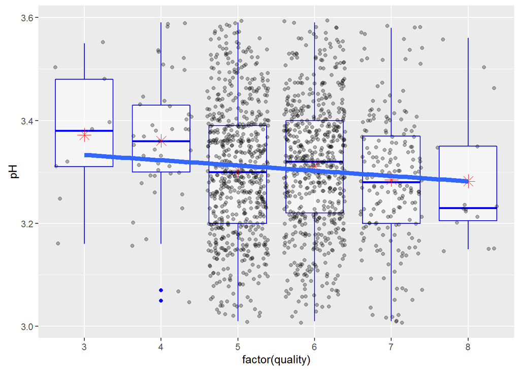

```
## wine$quality: 3
##    Min. 1st Qu.  Median    Mean 3rd Qu.    Max.
##   3.160   3.312   3.390   3.398   3.495   3.630
## --------------------------------------------------------
## wine$quality: 4
##    Min. 1st Qu.  Median    Mean 3rd Qu.    Max.
##   2.740   3.300   3.370   3.382   3.500   3.900
## --------------------------------------------------------
## wine$quality: 5
##    Min. 1st Qu.  Median    Mean 3rd Qu.    Max.
##   2.880   3.200   3.300   3.305   3.400   3.740
## --------------------------------------------------------
## wine$quality: 6
##    Min. 1st Qu.  Median    Mean 3rd Qu.    Max.
##   2.860   3.220   3.320   3.318   3.410   4.010
## --------------------------------------------------------
## wine$quality: 7
##    Min. 1st Qu.  Median    Mean 3rd Qu.    Max.
##   2.920   3.200   3.280   3.291   3.380   3.780
## --------------------------------------------------------
## wine$quality: 8
##    Min. 1st Qu.  Median    Mean 3rd Qu.    Max.
##   2.880   3.162   3.230   3.267   3.350   3.720
```

As the quality increases, the pH decreases eventhough this trend is not observe for wine from 5 and 6 qualities. The pH determines the acidity/basicity of a wine, low pH gives acidity and high gives basicity, usually the wine’s pH is around 3-4. Also the pH is a barrier for microbial growth, so having a low pH protect the wine from degradation.

### Total sulphur dioxide

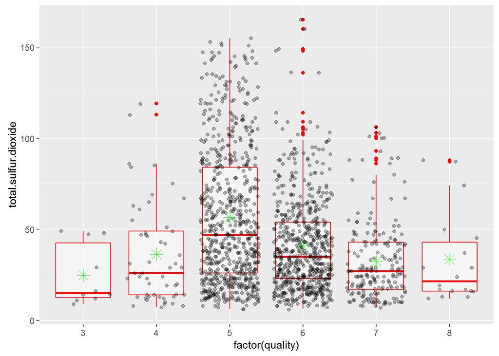

```
## wine$quality: 3
##    Min. 1st Qu.  Median    Mean 3rd Qu.    Max.
##     9.0    12.5    15.0    24.9    42.5    49.0
## --------------------------------------------------------
## wine$quality: 4
##    Min. 1st Qu.  Median    Mean 3rd Qu.    Max.
##    7.00   14.00   26.00   36.25   49.00  119.00
## --------------------------------------------------------
## wine$quality: 5
##    Min. 1st Qu.  Median    Mean 3rd Qu.    Max.
##    6.00   26.00   47.00   56.51   84.00  155.00
## --------------------------------------------------------
## wine$quality: 6
##    Min. 1st Qu.  Median    Mean 3rd Qu.    Max.
##    6.00   23.00   35.00   40.87   54.00  165.00
## --------------------------------------------------------
## wine$quality: 7
##    Min. 1st Qu.  Median    Mean 3rd Qu.    Max.
##    7.00   17.50   27.00   35.02   43.00  289.00
## --------------------------------------------------------
## wine$quality: 8
##    Min. 1st Qu.  Median    Mean 3rd Qu.    Max.
##   12.00   16.00   21.50   33.44   43.00   88.00
```

Looking at the boxplot we saw that the total sulfur dioxide increases from wine of 3 quality till 5 and then decreases till 8.

### Alcohol

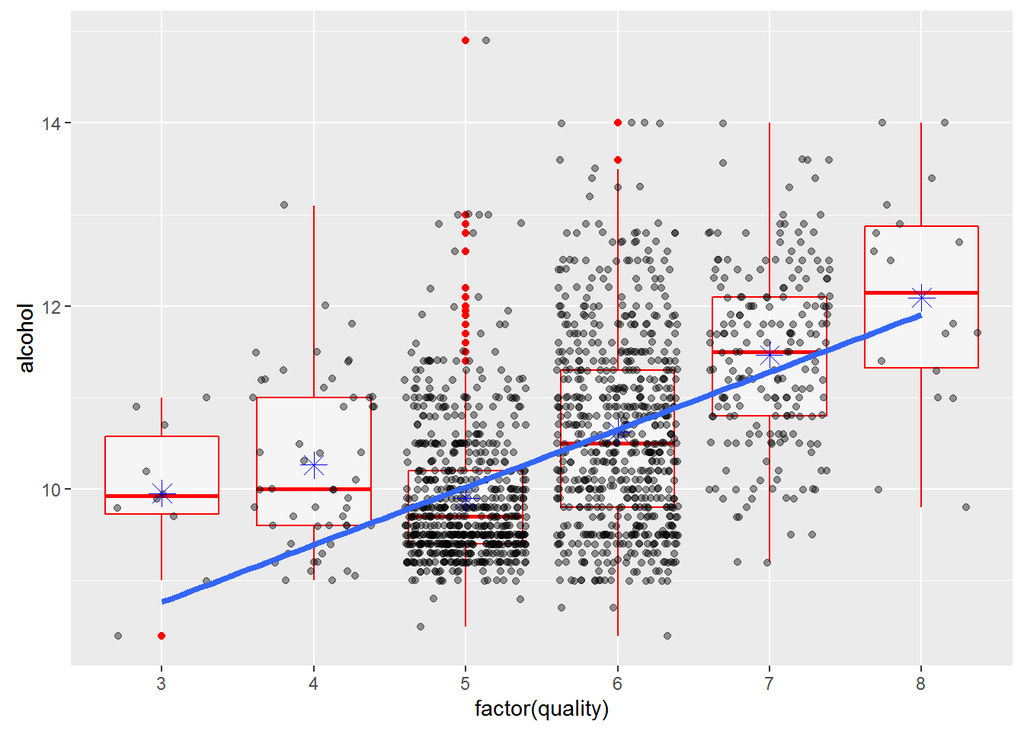

From 5 to 8 the alcohol increases with the quality, 3 and 4 have about the same percentage.

### Volatile acidity

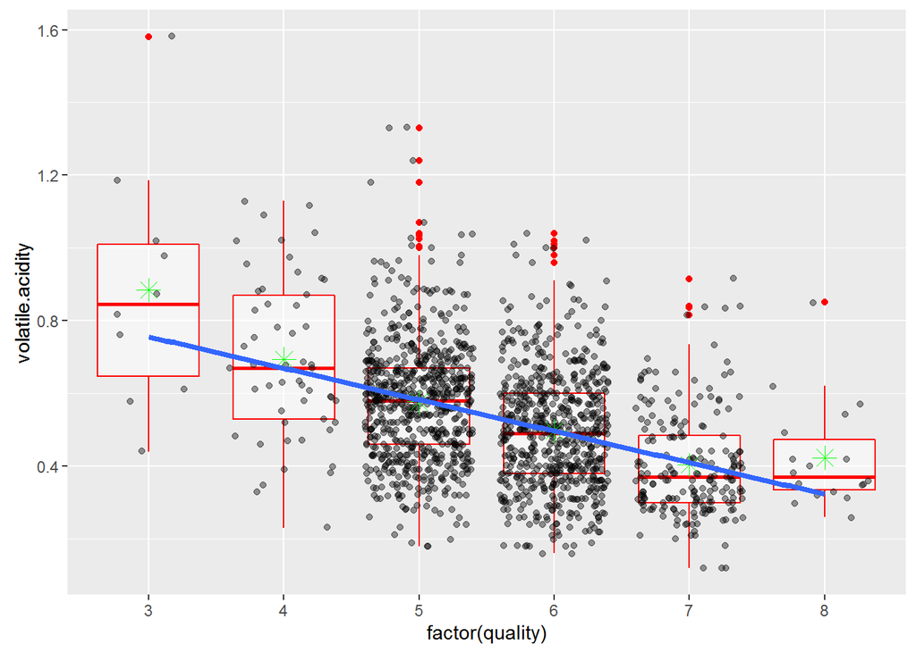

As the boxplot shows, the volatile acidity decreases with the increase of the quality.

### Citric acid

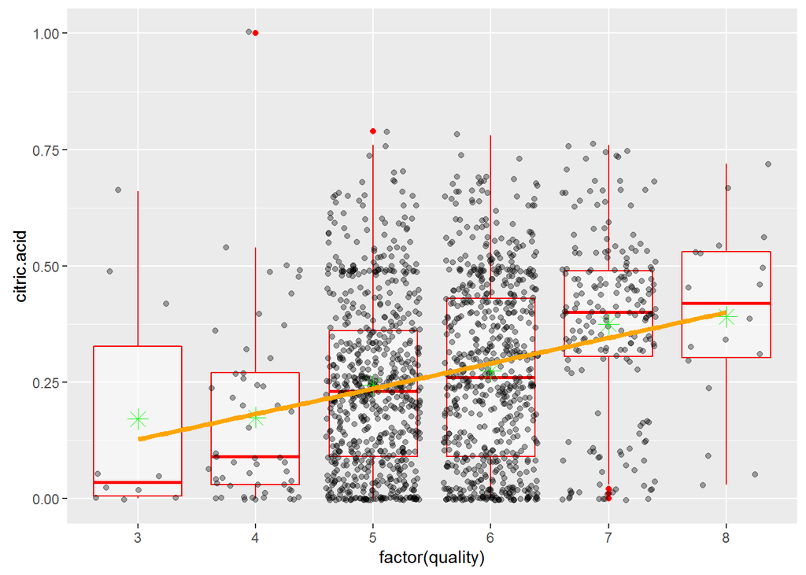

The high qualities wine have more citric acid. The citric acid increases with the quality.  
For the multivariate analysis I will first categorize the wine in 3 categories (3-4:low quality, 5-6: medium and 7-8: high)

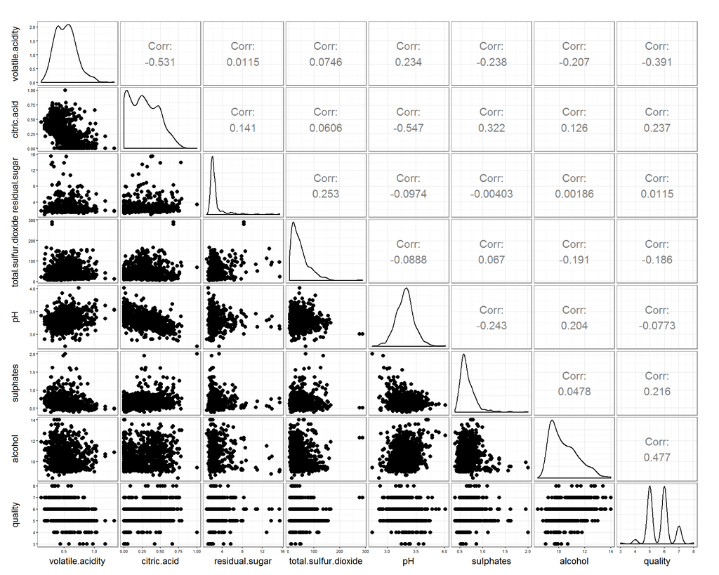

#### Strong correlation

```
##
##  Pearson's product-moment correlation
##
## data:  volatile.acidity and citric.acid
## t = -26.4891, df = 1597, p-value < 2.2e-16
## alternative hypothesis: true correlation is not equal to 0
## 95 percent confidence interval:
##  -0.5856550 -0.5174902
## sample estimates:
##        cor
## -0.5524957
```

```
##
##  Pearson's product-moment correlation
##
## data:  citric.acid and pH
## t = -25.7672, df = 1597, p-value < 2.2e-16
## alternative hypothesis: true correlation is not equal to 0
## 95 percent confidence interval:
##  -0.5756337 -0.5063336
## sample estimates:
##        cor
## -0.5419041
```

There is a negative correlation of citric acid with volatile acidity and pH. The correlation citric acid with volatile acidity is -0.55 and with pH is -0.54.

#### Weak correlation

```
##
##  Pearson's product-moment correlation
##
## data:  residual.sugar and total.sulfur.dioxide
## t = 8.2861, df = 1597, p-value = 2.22e-16
## alternative hypothesis: true correlation is not equal to 0
## 95 percent confidence interval:
##  0.1555549 0.2495652
## sample estimates:
##       cor
## 0.2030279
```

```
##
##  Pearson's product-moment correlation
##
## data:  pH and sulphates
## t = -8.015, df = 1597, p-value = 2.107e-15
## alternative hypothesis: true correlation is not equal to 0
## 95 percent confidence interval:
##  -0.2433231 -0.1490634
## sample estimates:
##        cor
## -0.1966476
```

There is weak positive correlation (0.20) of residual sugar with total sulfur dioxide and a negative correlation (-0.2) of pH with sulphates.

# Bivariate Analysis

### Talk about some of the relationships you observed in this part of the investigation. How did the feature(s) of interest vary with other features in the dataset?

In this part I observed that sulphates, alcohol and citric acid increase with the quality whereas the pH and volatile acidity decrease.

### Did you observe any interesting relationships between the other features (not the main feature(s) of interest)?

I also saw that the citric acid has a strong negative correlation with volatile acidity and pH. It’s also strange the up and down trend of the the total sulfur dioxide.

### What was the strongest relationship you found?

The correlation citric acid with volatile acidity and with pH were the strongest.

# Multivariate Plots Section

```
##
##  Pearson's product-moment correlation
##
## data:  volatile.acidity and citric.acid
## t = -4.6531, df = 61, p-value = 1.808e-05
## alternative hypothesis: true correlation is not equal to 0
## 95 percent confidence interval:
##  -0.6740989 -0.3023987
## sample estimates:
##        cor
## -0.5118165
```

```
##
##  Pearson's product-moment correlation
##
## data:  volatile.acidity and citric.acid
## t = -22.6062, df = 1317, p-value < 2.2e-16
## alternative hypothesis: true correlation is not equal to 0
## 95 percent confidence interval:
##  -0.5665378 -0.4887015
## sample estimates:
##        cor
## -0.5287303
```

```
##
##  Pearson's product-moment correlation
##
## data:  volatile.acidity and citric.acid
## t = -8.3488, df = 215, p-value = 8.413e-15
## alternative hypothesis: true correlation is not equal to 0
## 95 percent confidence interval:
##  -0.5891573 -0.3871249
## sample estimates:
##       cor
## -0.494798
```

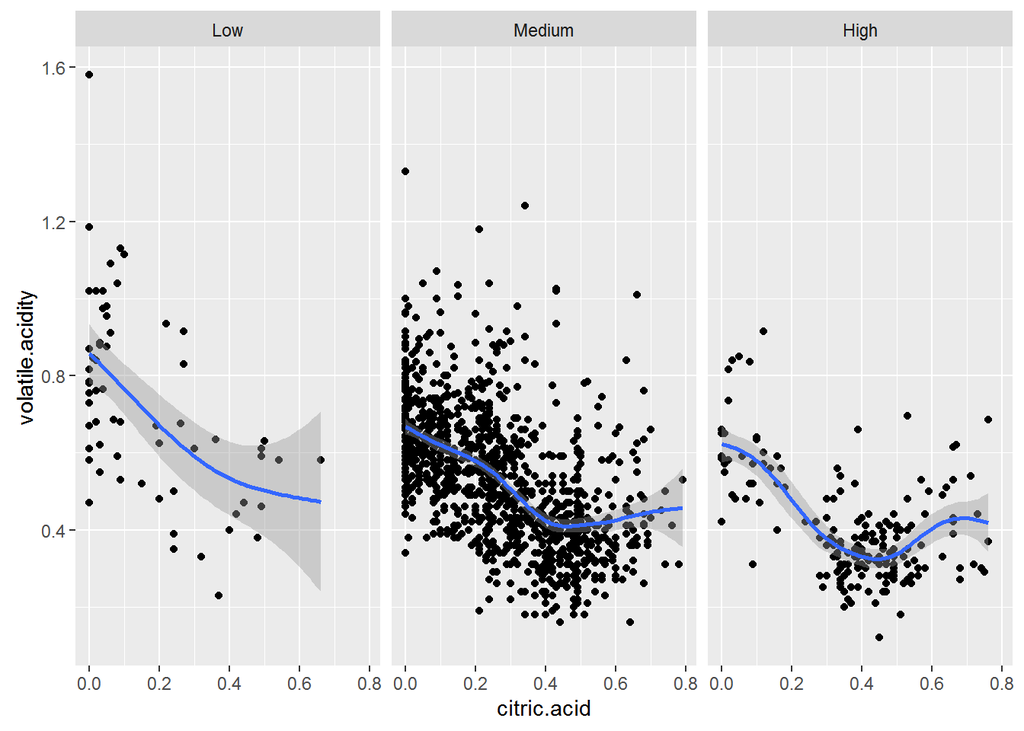

For the correlation citric acid and volatile acidity the correlation is more strong in wine of medium quality.

```
##
##  Pearson's product-moment correlation
##
## data:  pH and citric.acid
## t = -6.4332, df = 61, p-value = 2.161e-08
## alternative hypothesis: true correlation is not equal to 0
## 95 percent confidence interval:
##  -0.7633063 -0.4605656
## sample estimates:
##        cor
## -0.6357804
```

```
##
##  Pearson's product-moment correlation
##
## data:  pH and citric.acid
## t = -21.0984, df = 1317, p-value < 2.2e-16
## alternative hypothesis: true correlation is not equal to 0
## 95 percent confidence interval:
##  -0.5418820 -0.4611412
## sample estimates:
##        cor
## -0.5026068
```

```
##
##  Pearson's product-moment correlation
##
## data:  pH and citric.acid
## t = -15.2599, df = 215, p-value < 2.2e-16
## alternative hypothesis: true correlation is not equal to 0
## 95 percent confidence interval:
##  -0.7794057 -0.6503437
## sample estimates:
##       cor
## -0.721072
```

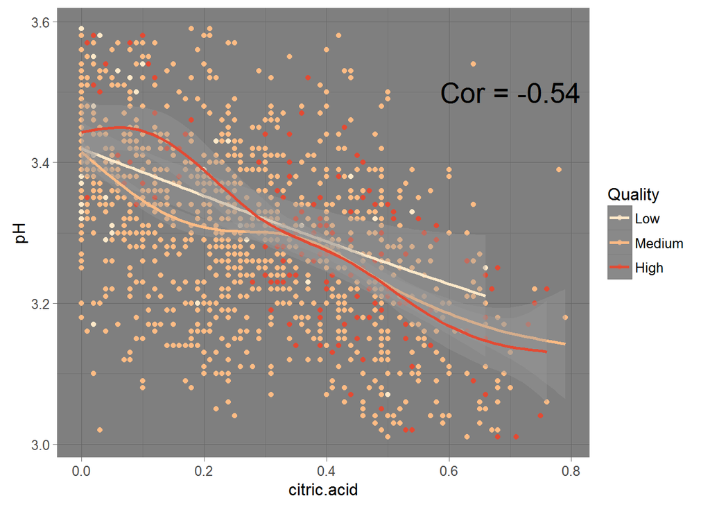

For citric acid and pH the strongest correlation is in wine of high quality. It’s more likely to found high quality wine with low pH and high citric acid.

[output not shown]

[output not shown]

[output not shown]

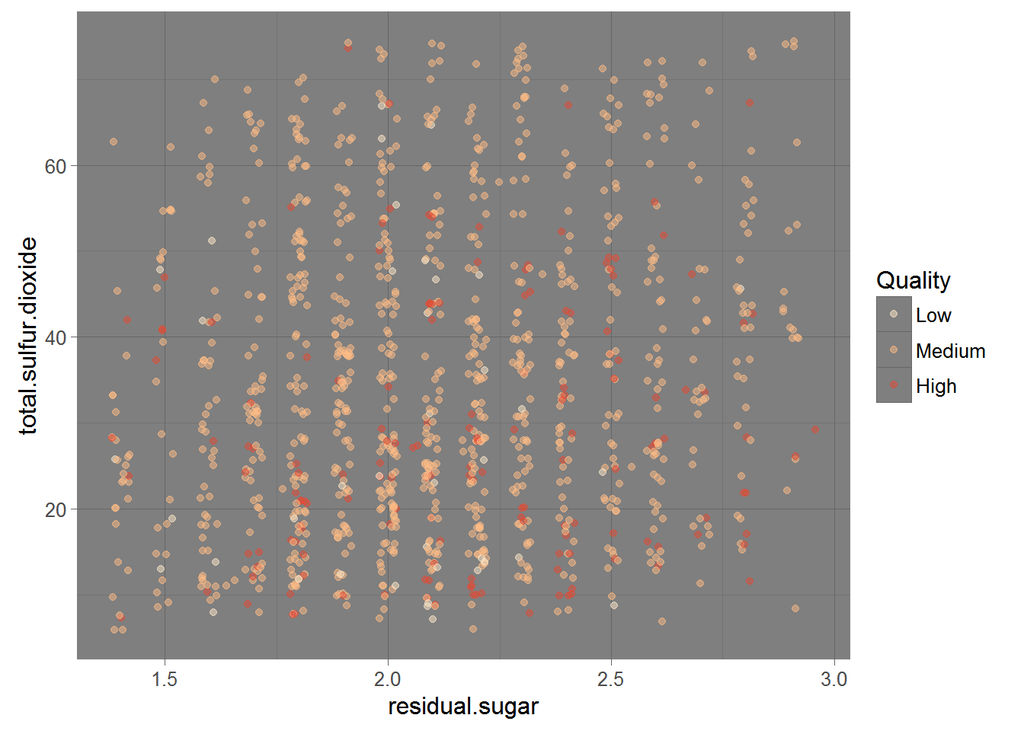

The scatterplot of total sulfur dioxide vs. residual sugar shows that medium quality wine is widely spread, low quality wines have a residual sugar less than 2.5 and total sulfur less than 60.

[figure not shown]

# Multivariate Analysis

### Were there any interesting or surprising interactions between features?

The interesting interactions were the strongest correlation that found. The suprising thing is that the correlation pH and citric.acid vary a lot among the quality, probably because of the variance between each type.

# Final Plots and Summary

### Plot One

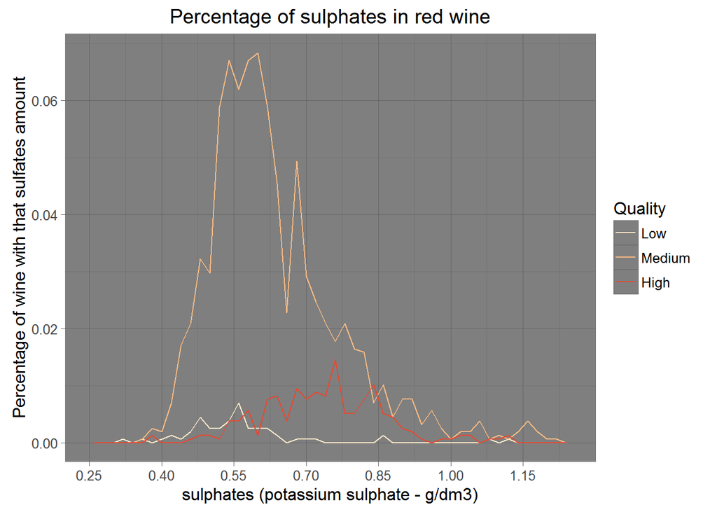

### Plot Two

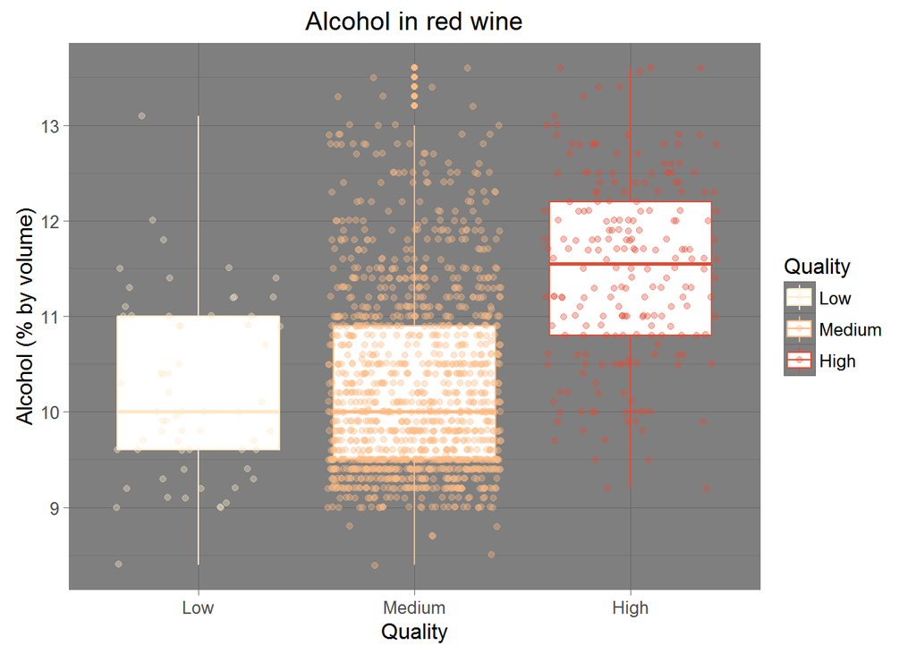

### Description Two

The alcohol percent is high in high quality wines. The low and medium wines quality have the same median.

### Plot Three

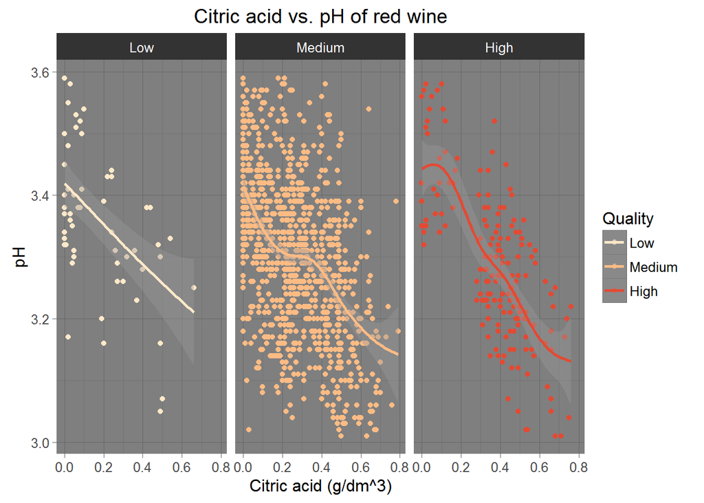

### Description Three

The pH decreases as the citric acid increases and this relationship is more strong in high quality wines. It’s more likely to found high quality wine with low pH and high citric acid. Medium and high a range from 0 to 0.8 of citric acid.

# Reflection

I used univariate, bivariate and multivariate analysis to found the most important parameters defining the wine quality. Using the bivariate analysis some trends were very clear. Red wine quality is mostly influenced by the sulphate content, pH, alcohol, volatile acidity and total.sulfur.dioxide. It was difficult to find the better way of visualization of each features because some distribution were skewed. I struggled understanding why the correlation of the citric acid with pH is so different among the different quality, looking at the scatterplot separetly I saw that their distribution are different and also there are few wine of low quality.  
This analysis can be useful to verify the authenticity and quality of red wine, but there are some limitations of the data. First, the observations is unbalanced, we have few observations of low and high quality wine, this can give some bias on the analysis. Finally it could be also good to have an idea of the law limits of each parameters in that country in order to remove it from the analysis. In the future this data could be use for machine learning, to classify and predict the wine quality.